# homework

# HW10

## Solution to Exercise 2 (page 204, Advanced R).

We can do this to apply it to each column of a dataframe after loading package purrr:  
purrr::modify(df)  
where df is name of the dataframe.  
To apply it only to numeric column we can use the function modify_if() :  
modify_if(df, is.numeric, scale01)  
where df is name of the dataframe.

## Solution to Exercise 1 (page 213, Advanced R) a.

We use vapply() as follows:

```r
# we first create a sample matrix for demonstration:
mymat = matrix(rnorm(12),3,4)
colnames(mymat) = c("col1","col2","col3","col4")
mydf = as.data.frame(mymat)  # my dataframe

# to compute sd of each column in a numeric data frame:
vapply(mydf, sd, numeric(1))
```

```
##      col1      col2      col3      col4
## 1.5381646 0.7142579 0.7476979 0.5861589
```

## Solution to Exercise 1 (page 213, Advanced R) b.

we use vapply() twice as follows:

```r
# we first create another sample matrix for demonstration:
mymat = matrix(rnorm(12),3,4)
colnames(mymat) = c("col1","col2","col3","col4")
mydf = cbind(as.data.frame(mymat),col5=c("Not","Numeric","here!"))  # my dataframe
print(mydf)
```

```
##         col1        col2      col3       col4    col5
## 1  0.3317253 -0.92890721  1.139342 -0.3376388     Not
## 2 -1.3300611 -0.23050097 -0.485003 -1.5830669 Numeric
## 3  0.7983552  0.07316351 -1.713495  0.1740910   here!
```

```r
print("we can see that this dataframe does not contain numeric columns only!")
```

```
## [1] "we can see that this dataframe does not contain numeric columns only!"
```

```r
# to compute sd of each column in a numeric data frame:
vapply(mydf[vapply(mydf, is.numeric, logical(1))],
       sd, numeric(1))
```

```
##      col1      col2      col3      col4
## 1.1187369 0.5138302 1.4309887 0.9037480
```

```r
# remove all at the end:
rm(list=ls())
```

## Exercise THREE.

Implement a Gibbs sampler to generate a bivariate normal chain $( X_t,Y_t ) $ with zero means, unit standard deviations, and correlation 0.9.

**Exercise <1>:**

<1> Write an Rcpp function.  
### Solution: The required Rcpp function is written and saved in gibbsC.cpp.

```r
library(Rcpp)
sourceCpp('../src/gibbsC.cpp')
```

**Exercise <2>:**

<2> Compare the corresponding generated random numbers with the pure R language using the function “qqplot”.

### Solution:

```r
# FIRST, WE OBTAIN THE SAMPLE USING PURE R:

# R function for gibbs sampler:
my_gibbs_xy_r = function(mu, sig, rho, init0, N,seed=NULL) {
  # gibbs sampler for data generation in R
  # mu,sig and rho being parameters for distribution,init0 being initials and N being length of chain
  set.seed(seed)
  s = sqrt(1 - rho^2) * sig
  X = Y = numeric(N)
  X[1] = init0[1]; Y[1] = init0[2]
  for (i in 2:N) {
    y = Y[i-1]
    m1 = mu[1] + rho * (y - mu[2]) * sig[1] / sig[2]
    X[i] = rnorm(1, m1, s[1])
    x = X[i]
    m2 = mu[2] + rho * (x - mu[1]) * sig[2] / sig[1]
    Y[i] = rnorm(1, m2, s[2])
  }
  return(list(X = X, Y = Y))
}
# data gerneration in R:
N = 1e3;b = 1000;rho = 0.9;mu = c(0, 0);sigma = c(1, 1)
my_chainR = my_gibbs_xy_r(mu, sigma, rho, c(0,0), N)


# NOW WE OBTAIN SAMPLE WITH Rcpp:

mychainC=gibbsC(0,0,1,1,0.9,0,0,1000)
mychainC=as.data.frame(mychainC)
colnames(mychainC) = c('x','y')
```

And here is the result of comparison:

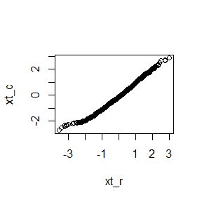

```r
# NOW WE MAKE QQPLOT:
# qqplot of x_t vs x_t:
xt_r = my_chainR$X
xt_c = mychainC$x
qqplot(xt_r,xt_c)
```

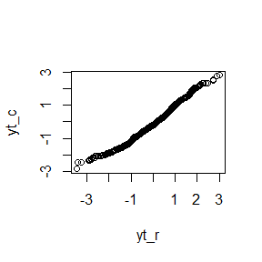

```r
# qqplot of y_t vs y_t:
yt_r = my_chainR$Y
yt_c = mychainC$y
qqplot(yt_r,yt_c)
```

**Exercise <3>:**  
<3> Compare the computation time of the two functions with the function “microbenchmark”.  
**Solution:**

```r
library(microbenchmark)
ts <- microbenchmark('with Pure R'=my_gibbs_xy_r(mu, sigma, rho, c(0,0), N),
                     'with Rcpp'=gibbsC(0,0,1,1,0.9,0,0,100))
summary(ts)[,c(1,3,5,6)]
```

```
##          expr       lq   median       uq
## 1 with Pure R 3439.050 3691.450 4715.651
## 2   with Rcpp   26.601   30.801   36.901
```

From this coputation time comparisom above we can see that computing with Rcpp is significantly faster.

```r
# remove all at the end:
rm(list=ls())
```